# Machine learning prediction

This is to project to do prediction of exercise by machine learning. The source is from http://groupware.les.inf.puc-rio.br/har.

## The strategy

- Data cleaning
- Data splitting for train and test
- model selection
- Cross validation
- Prediction

Let ’s first have all necessary package ready.

### Data cleaning and exploring

Due to missing values of many variables as well as some variable won’t be meaningful for the prediction, we drop those variables then we split our dataset to training and testing part.

The distribution of the classes is shown as:

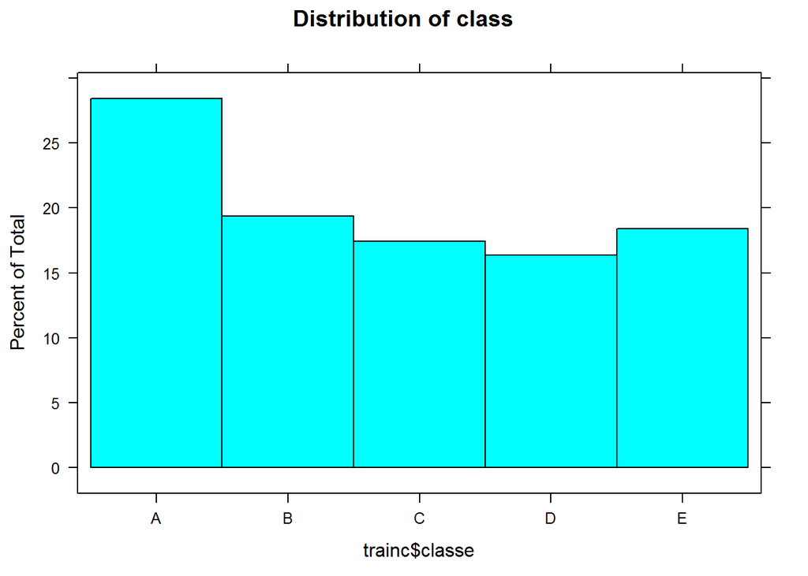

```r
histogram(trainc$classe,main='Distribution of class' )
```

### model building

```r
set.seed(825)
control <- trainControl(method = "repeatedcv",number=5,repeats=5)
modFit <- train(classe~.,data=trialp,preProcess='pca',prox=TRUE)
modFit$finalModel
```

```
##
## Call:
##  randomForest(x = x, y = y, mtry = param$mtry, proximity = TRUE)
##                Type of random forest: classification
##                      Number of trees: 500
## No. of variables tried at each split: 2
##
##         OOB estimate of  error rate: 10.9%
## Confusion matrix:
##     A   B   C   D   E class.error
## A 785  14  14  20   4     0.06213
## B  42 490  31   2   5     0.14035
## C   9  26 458  12   9     0.10895
## D   4   6  46 413  14     0.14493
## E   8  23  16  16 479     0.11624
```

```r
predf <- predict(modFit,trialpt)

confusionMatrix(trialpt$classe,predf)
```

```
## Confusion Matrix and Statistics
##
##           Reference
## Prediction    A    B    C    D    E
##          A 3157   52   40   88   11
##          B  155 1963  112   11   37
##          C   38  140 1807   47   21
##          D   23   35  198 1652   21
##          E   14   93   59   43 1955
##
## Overall Statistics
##
##                Accuracy : 0.895
##                  95% CI : (0.889, 0.9)
##     No Information Rate : 0.288
##     P-Value [Acc > NIR] : <2e-16
##
##                   Kappa : 0.867
##  Mcnemar's Test P-Value : <2e-16
##
## Statistics by Class:
##
##                      Class: A Class: B Class: C Class: D Class: E
## Sensitivity             0.932    0.860    0.815    0.897    0.956
## Specificity             0.977    0.967    0.974    0.972    0.979
## Pos Pred Value          0.943    0.862    0.880    0.856    0.903
## Neg Pred Value          0.973    0.966    0.958    0.981    0.991
## Prevalence              0.288    0.194    0.188    0.156    0.174
## Detection Rate          0.268    0.167    0.153    0.140    0.166
## Detection Prevalence    0.284    0.194    0.174    0.164    0.184
## Balanced Accuracy       0.955    0.913    0.895    0.935    0.967
```

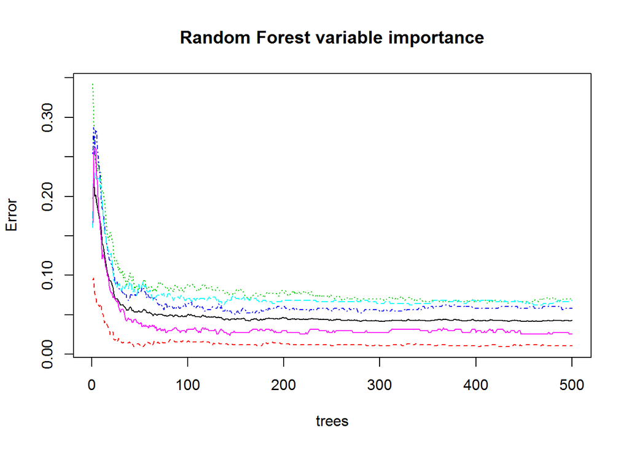

```r
set.seed(825)
rf <- randomForest(classe~.,data=trialp)
plot(rf,main='Random Forest variable importance')
```

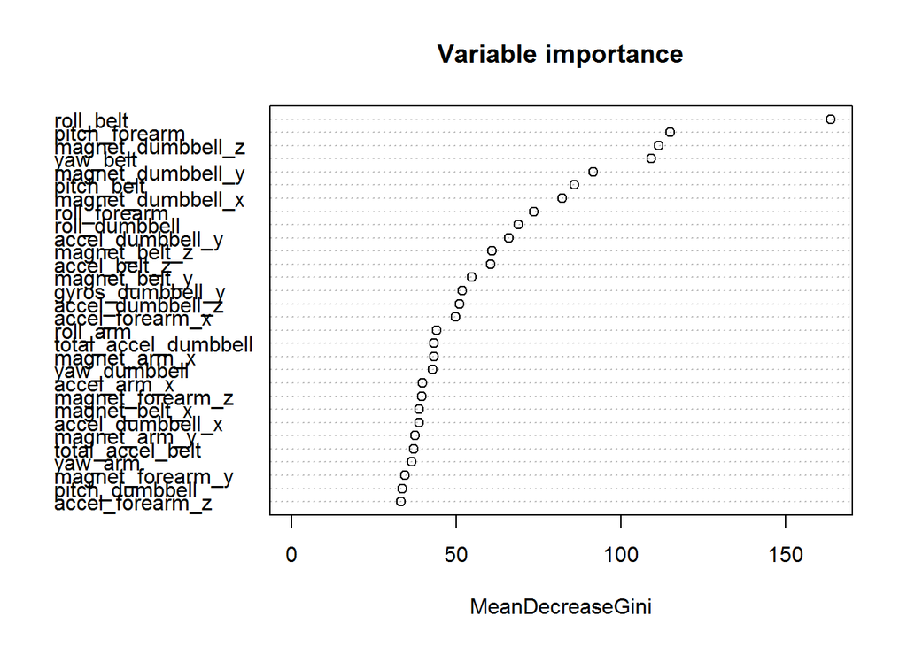

```r
#rf$finalModel
varImpPlot(rf,main='Variable importance')
```

```r
predrf <- predict(rf,trialpt)
confusionMatrix(trialpt$classe,predrf)
```

```
## Confusion Matrix and Statistics
##
##           Reference
## Prediction    A    B    C    D    E
##          A 3321    8   15    3    1
##          B   72 2132   65    4    5
##          C    4   73 1958   17    1
##          D    3    0   82 1842    2
##          E    1   12    4   22 2125
##
## Overall Statistics
##
##                Accuracy : 0.967
##                  95% CI : (0.963, 0.97)
##     No Information Rate : 0.289
##     P-Value [Acc > NIR] : <2e-16
##
##                   Kappa : 0.958
##  Mcnemar's Test P-Value : <2e-16
##
## Statistics by Class:
##
##                      Class: A Class: B Class: C Class: D Class: E
## Sensitivity             0.976    0.958    0.922    0.976    0.996
## Specificity             0.997    0.985    0.990    0.991    0.996
## Pos Pred Value          0.992    0.936    0.954    0.955    0.982
## Neg Pred Value          0.991    0.990    0.983    0.995    0.999
## Prevalence              0.289    0.189    0.180    0.160    0.181
## Detection Rate          0.282    0.181    0.166    0.156    0.181
## Detection Prevalence    0.284    0.194    0.174    0.164    0.184
## Balanced Accuracy       0.987    0.971    0.956    0.983    0.996
```

```r
predtf <- predict(rf,trialtest)
confusionMatrix(trialtest$classe,predtf)
```

```
## Confusion Matrix and Statistics
##
##           Reference
## Prediction    A    B    C    D    E
##          A 1382    5    7    0    1
##          B   28  897   22    2    0
##          C    0   22  826    6    1
##          D    1    1   28  772    2
##          E    2    1   16    2  880
##
## Overall Statistics
##
##                Accuracy : 0.97
##                  95% CI : (0.965, 0.975)
##     No Information Rate : 0.288
##     P-Value [Acc > NIR] : < 2e-16
##
##                   Kappa : 0.962
##  Mcnemar's Test P-Value : 6.93e-08
##
## Statistics by Class:
##
##                      Class: A Class: B Class: C Class: D Class: E
## Sensitivity             0.978    0.969    0.919    0.987    0.995
## Specificity             0.996    0.987    0.993    0.992    0.995
## Pos Pred Value          0.991    0.945    0.966    0.960    0.977
## Neg Pred Value          0.991    0.993    0.982    0.998    0.999
## Prevalence              0.288    0.189    0.183    0.159    0.180
## Detection Rate          0.282    0.183    0.168    0.157    0.179
## Detection Prevalence    0.284    0.194    0.174    0.164    0.184
## Balanced Accuracy       0.987    0.978    0.956    0.990    0.995
```